# Sampling recordings - Multple Time Periods

This brief vignette shows an example of a basic workflow selecting recordings for different times of day by site and year.

First we’ll load the packages we want to work with

```r
library(ARUtools)
library(dplyr)
library(purrr)
library(tidyr)
library(glue)
library(lubridate)
```

Next we’ll prepare our metadata on the recordings, by cleaning, adding site-level information and calculating the time to sunrise/sunset for each file. We’ll also define recordings as either ‘early’ (occurring before 6am) or ‘late’ (occurring after 6am).

```r
s <- clean_site_index(example_sites_clean,
  name_date = c("date_time_start", "date_time_end")
)
m <- clean_metadata(project_files = example_files) |>
  add_sites(s) |>
  calc_sun() |>
  mutate(
    time_period = if_else(hour(date_time) < 6, "early", "late"),
    year = year(date)
  )
```

```
#> Extracting ARU info...
#> Extracting Dates and Times...
```

```r
m
```

```
#> # A tibble: 42 × 18
#>   file_name     type  path  aru_id manufacturer model aru_type site_id tz_offset
#>   <chr>         <chr> <chr> <chr>  <chr>        <chr> <chr>    <chr>   <chr>
#> 1 P01_1_202005… wav   a_BA… BARLT… Frontier La… BAR-… BARLT    P01_1   -0400
#> 2 P01_1_202005… wav   a_BA… BARLT… Frontier La… BAR-… BARLT    P01_1   -0400
#> 3 P02_1_202005… wav   a_S4… S4A01… Wildlife Ac… Song… SongMet… P02_1   <NA>
#> 4 P02_1_202005… wav   a_S4… S4A01… Wildlife Ac… Song… SongMet… P02_1   <NA>
#> # ℹ 38 more rows
#> # ℹ 9 more variables: date_time <dttm>, date <date>, longitude <dbl>,
#> #   latitude <dbl>, tz <chr>, t2sr <dbl>, t2ss <dbl>, time_period <chr>,
#> #   year <dbl>
```

Time to do some sampling!

First we **define the selection parameters** for each time frame we’re interested in sampling. This might be “dawn” and “dusk”, or in this example, “early” and “late” morning.

This function will also **simulate** the selection weights so we can see what we’ve defined.

```r
p <- list(
  "early" = sim_selection_weights(min_range = c(-70, 240)),
  "late" = sim_selection_weights(min_range = c(100, 300), min_mean = 200)
)
```

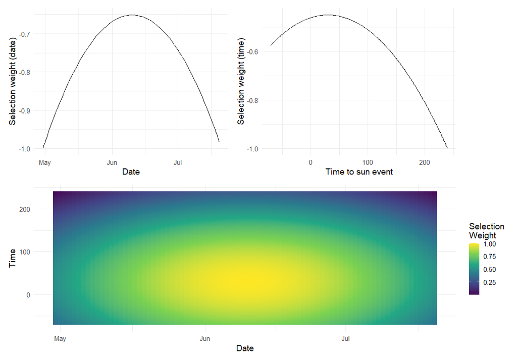

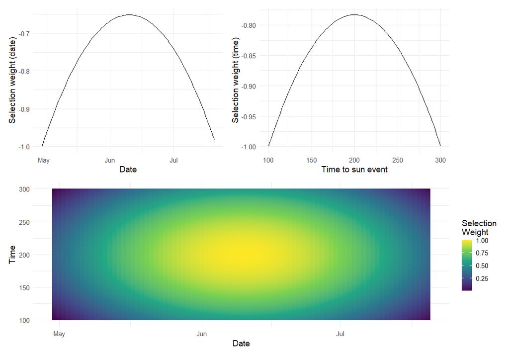

```r
p
```

```
#> $early
#> $early$min_range
#> [1] -70 240
#>
#> $early$min_mean
#> [1] 30
#>
#> $early$min_sd
#> [1] 60
#>
#> $early$day_range
#> [1] 120 201
#>
#> $early$day_mean
#> [1] 161
#>
#> $early$day_sd
#> [1] 20
#>
#> $early$offset
#> [1] 0
#>
#> $early$return_log
#> [1] TRUE
#>
#> $early$selection_fun
#> [1] "norm"
#>
#>
#> $late
#> $late$min_range
#> [1] 100 300
#>
#> $late$min_mean
#> [1] 200
#>
#> $late$min_sd
#> [1] 60
#>
#> $late$day_range
#> [1] 120 201
#>
#> $late$day_mean
#> [1] 161
#>
#> $late$day_sd
#> [1] 20
#>
#> $late$offset
#> [1] 0
#>
#> $late$return_log
#> [1] TRUE
#>
#> $late$selection_fun
#> [1] "norm"
```

Now we can **calculate selection weights**

Here we’ll calculate a separate set of selection weights for early and late recordings in each year. Then we’ll group recordings by site, year, and time period.

```r
w <- m |>
  nest(data = c(-time_period, -year)) |>
  mutate(
    params = p,
    sel = map2(data, params, calc_selection_weights)
  ) |>
  unnest(sel) |>
  select(-"data", -"params") |>
  mutate(selection_group = glue("{site_id}_{year}_{time_period}"))
w
```

```
#> # A tibble: 21 × 27
#>   time_period  year file_name     type  path  aru_id manufacturer model aru_type
#>   <chr>       <dbl> <chr>         <chr> <chr> <chr>  <chr>        <chr> <chr>
#> 1 early        2020 P01_1_202005… wav   a_BA… BARLT… Frontier La… BAR-… BARLT
#> 2 early        2020 P02_1_202005… wav   a_S4… S4A01… Wildlife Ac… Song… SongMet…
#> 3 early        2020 P06_1_202005… wav   a_BA… BARLT… Frontier La… BAR-… BARLT
#> 4 early        2020 P07_1_202005… wav   a_S4… S4A01… Wildlife Ac… Song… SongMet…
#> # ℹ 17 more rows
#> # ℹ 18 more variables: site_id <chr>, tz_offset <chr>, date_time <dttm>,
#> #   date <date>, longitude <dbl>, latitude <dbl>, tz <chr>, t2sr <dbl>,
#> #   t2ss <dbl>, doy <dbl>, psel_by <chr>, psel_min <dbl>, psel_doy <dbl>,
#> #   psel <dbl>, psel_scaled <dbl>, psel_std <dbl>, psel_normalized <dbl>,
#> #   selection_group <glue>
```

This `w` data sets contains the original sampling recordings, but now also new columns containing various measures of the probability of selection.

We’ll **define the number of samples** we’d like to have.

```r
n <- w |>
  summarize(n_recordings = n(), .by = c("selection_group", "time_period")) |>
  mutate(
    n = if_else(time_period == "early", 5, 2),
    n_os = if_else(time_period == "early", floor(n * 1 / 3), floor(n * 1 / 4)),
    n_os = pmax(0, pmin(n_recordings - n, round(n / 3))),
    n = pmin(n, n_recordings)
  )
n
```

```
#> # A tibble: 7 × 5
#>   selection_group  time_period n_recordings     n  n_os
#>   <glue>           <chr>              <int> <dbl> <dbl>
#> 1 P01_1_2020_early early                  3     3     0
#> 2 P02_1_2020_early early                  3     3     0
#> 3 P06_1_2020_early early                  3     3     0
#> 4 P07_1_2020_early early                  3     3     0
#> # ℹ 3 more rows
```

And finally **sample the recordings**!

```r
g <- sample_recordings(w, n,
  col_site_id = selection_group,
  col_sel_weights = psel_normalized
)
g
```

```
#> Summary of Site Counts:
#>
#> siteuse by total:
#>       Base Over
#> total   19    2
#>
#> siteuse by stratum:
#>                  Base Over
#> P01_1_2020_early    3    0
#> P02_1_2020_early    3    0
#> P03_1_2020_late     2    1
#> P06_1_2020_early    3    0
#> P07_1_2020_early    3    0
#> P08_1_2020_late     2    1
#> P09_1_2020_early    3    0
```

The recordings selected for sampling…

```r
g$sites_base
```

```
#> Simple feature collection with 19 features and 35 fields
#> Geometry type: POINT
#> Dimension:     XY
#> Bounding box:  xmin: 124 ymin: -53.21667 xmax: 132 ymax: 238.3167
#> Projected CRS: WGS 84 / World Mercator
#> First 10 features:
#>       siteID siteuse replsite   lon_WGS84     lat_WGS84          stratum wgt ip
#> 1  sample-01    Base     None 0.001113911 -4.812753e-04 P01_1_2020_early   1  1
#> 2  sample-02    Base     None 0.001113911 -4.812753e-04 P01_1_2020_early   1  1
#> 3  sample-03    Base     None 0.001113911 -4.812753e-04 P01_1_2020_early   1  1
#> 4  sample-04    Base     None 0.001122894 -4.273146e-04 P02_1_2020_early   1  1
#> 5  sample-05    Base     None 0.001122894 -4.273146e-04 P02_1_2020_early   1  1
#> 6  sample-06    Base     None 0.001122894 -4.273146e-04 P02_1_2020_early   1  1
#> 7  sample-07    Base     None 0.001167810  3.240657e-05 P06_1_2020_early   1  1
#> 8  sample-08    Base     None 0.001167810  3.240657e-05 P06_1_2020_early   1  1
```

[output cut: 68 more lines]